# Amandeep Descriptive

```python
import pandas as pd
import numpy as np
import seaborn as sns
import statistics as stat
import matplotlib.pyplot as plt
from scipy.stats import boxcox
from sklearn.preprocessing import LabelEncoder
from sklearn.preprocessing import StandardScaler
from sklearn.preprocessing import MinMaxScaler
```

Q1. Import the attached CSV files (Diamond.csv) and answer the following questions

```python
a=pd.read_excel(r"C:\Users\chauh\Downloads\Diamonds.xlsx")
a.head(5)
```

|  | carat | cut | color | clarity | depth | table | weight | size | price |
| --- | --- | --- | --- | --- | --- | --- | --- | --- | --- |
| 0 | 0.23 | Ideal | E | SI2 | 61.5 | 55.0 | 3.95 | 3.98 | 326 |
| 1 | 0.21 | Premium | E | SI1 | 59.8 | 61.0 | 3.89 | 3.84 | 326 |
| 2 | 0.23 | Good | E | VS1 | 56.9 | 65.0 | 4.05 | 4.07 | 327 |
| 3 | 0.29 | Premium | I | VS2 | 62.4 | 58.0 | 4.20 | 4.23 | 334 |
| 4 | 0.31 | Good | J | SI2 | 63.3 | 58.0 | 4.34 | 4.35 | 335 |

A. Create 2 dataframes out of this dataframe – 1 with all numerical variables and other with all categorical variables.

```python
cat_columns= [ i for i in a.columns if a[i].dtypes=='object']
num_columns=[ i for i in a.columns if a[i].dtypes!='object']
```

```python
cat_variables=a[cat_columns]
cat_variables.head(5)
```

|  | cut | color | clarity |
| --- | --- | --- | --- |
| 0 | Ideal | E | SI2 |
| 1 | Premium | E | SI1 |
| 2 | Good | E | VS1 |
| 3 | Premium | I | VS2 |
| 4 | Good | J | SI2 |

```python
num_variables=a[num_columns]
num_variables.head(5)
```

|  | carat | depth | table | weight | size | price |
| --- | --- | --- | --- | --- | --- | --- |
| 0 | 0.23 | 61.5 | 55.0 | 3.95 | 3.98 | 326 |
| 1 | 0.21 | 59.8 | 61.0 | 3.89 | 3.84 | 326 |
| 2 | 0.23 | 56.9 | 65.0 | 4.05 | 4.07 | 327 |
| 3 | 0.29 | 62.4 | 58.0 | 4.20 | 4.23 | 334 |
| 4 | 0.31 | 63.3 | 58.0 | 4.34 | 4.35 | 335 |

B. Calculate the measure of central tendency of numerical variables using Pandas and statistics libraries and check if the calculated values are different between these 2 libraries

```python
#Mean from pandas
num_variables.mean()
```

```
carat        0.797940
depth       61.749405
table       57.457184
weight       5.731157
size         5.734526
price     3932.799722
dtype: float64
```

```python
#Mean from Stats
print('carat mean',stat.mean(num_variables['carat']))
print('depth mean',stat.mean(num_variables['depth']))
print('table mean',stat.mean(num_variables['table']))
print('weight mean',stat.mean(num_variables['weight']))
print('size mean',stat.mean(num_variables['size']))
print('price mean',stat.mean(num_variables['price']))
```

```
carat mean 0.7979397478680015
depth mean 61.74940489432703
table mean 57.45718390804598
weight mean 5.731157211716722
size mean 5.734525954764553
price mean 3932.799721913237
```

```python
#Median from pandas
num_variables.median()
```

```
carat        0.70
depth       61.80
table       57.00
weight       5.70
size         5.71
price     2401.00
dtype: float64
```

```python
#Median from Stats
print('carat median',stat.median(num_variables['carat']))
print('depth median',stat.median(num_variables['depth']))
print('table median',stat.median(num_variables['table']))
print('weight median',stat.median(num_variables['weight']))
print('size median',stat.median(num_variables['size']))
print('price median',stat.median(num_variables['price']))
```

```
carat median 0.7
depth median 61.8
table median 57.0
weight median 5.7
size median 5.71
price median 2401.0
```

```python
#Mode from pandas
num_variables.mode()
```

|  | carat | depth | table | weight | size | price |
| --- | --- | --- | --- | --- | --- | --- |
| 0 | 0.3 | 62.0 | 56.0 | 4.37 | 4.34 | 605 |

```python
#Mode from Stats
print('carat mode',stat.mode(num_variables['carat']))
print('depth mode',stat.mode(num_variables['depth']))
print('table mode',stat.mode(num_variables['table']))
print('weight mode',stat.mode(num_variables['weight']))
print('size mode',stat.mode(num_variables['size']))
print('price mode',stat.mode(num_variables['price']))
```

```
carat mode 0.3
depth mode 62.0
table mode 56.0
weight mode 4.37
size mode 4.34
price mode 605
```

C. Check the skewness of all numeric variables. Mention against each variable if its highly skewed/light skewed/ Moderately skwewed.

```
carat     1.116646
depth    -0.082294
table     0.796896
weight    0.378676
size      2.434167
price     1.618395
dtype: float64
```

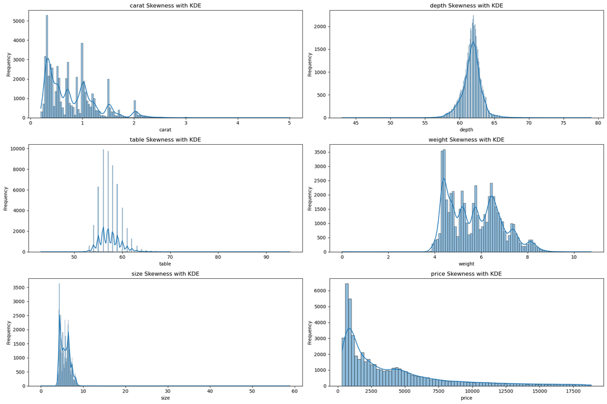

```python
plt.figure(figsize=(18, 12))
print(num_variables.skew())
for i, column in enumerate(num_variables, 1):
    plt.subplot(3, 2, i)
    sns.histplot(num_variables[column], kde=True)
    plt.title(f'{column} Skewness with KDE')
    plt.xlabel(column)
    plt.ylabel('Frequency')

plt.tight_layout()
plt.show()
```

```python
# from above charts and skew table we can say that  Depth and weight is lightly skewed
# table is moderatley skewed.
# carat, size and price is highly skewed.
```

D. Use the different transformation techniques to convert skewed data found in previous question into normal distribution

```
carat     0.580654
depth    -0.359117
table     0.602231
weight   -0.073063
size      0.006600
price     0.115926
dtype: float64
```

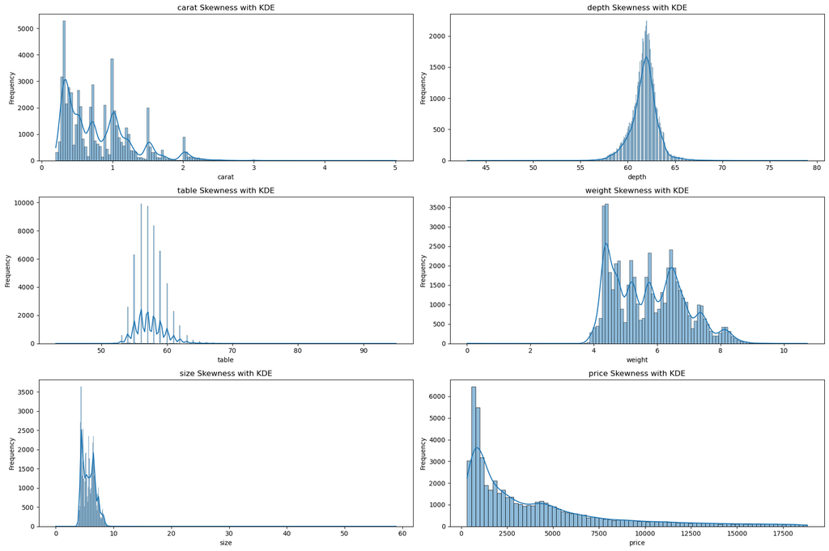

```python
#skewness transformation from log
plt.figure(figsize=(18, 12))
num_variables_log=np.log(num_variables+1)
print(num_variables_log.skew())
for i, column in enumerate(num_variables_log, 1):
    plt.subplot(3, 2, i)
    sns.histplot(num_variables[column], kde=True)
    plt.title(f'{column} Skewness with KDE')
    plt.xlabel(column)
    plt.ylabel('Frequency')

plt.tight_layout()
plt.show()
```

```
transformed_skew
-0.0008065967961745981
```

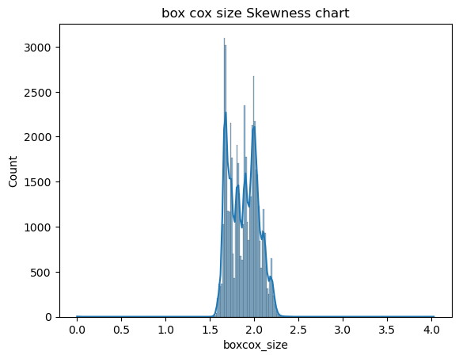

```python
#transformed skewness through boxcox
num_variables['boxcox_size'], _ = boxcox(num_variables['size'] + 1)

transformed_skew= num_variables['boxcox_size'].skew()
print('transformed_skew')
print(transformed_skew)
sns.histplot(num_variables['boxcox_size'], kde=True)
plt.title('box cox size Skewness chart')
plt.show()
```

E. Create a user defined function in python to check the outliers using IQR method. Then pass all numeric variables in that function to check outliers

```python
def detect_outliers_iqr(dataframe, column):
    q1 = dataframe[column].quantile(0.25)
    q3 = dataframe[column].quantile(0.75)
    iqr = q3 - q1
    lower_bound = q1 - 1.5 * iqr
    upper_bound = q3 + 1.5 * iqr
    outliers = dataframe[(dataframe[column] < lower_bound) | (dataframe[column] > upper_bound)][column]
    return { "Lower Bound": lower_bound,
        "Upper Bound": upper_bound,
        "Outliers": outliers.tolist()}
outlier_results = {}
for column in num_variables.columns:
    outlier_results[column] = detect_outliers_iqr(num_variables, column)
for col, result in outlier_results.items():
    print(f"Column: {col}")
    print(f"Lower Bound: {result['Lower Bound']}")
    print(f"Upper Bound: {result['Upper Bound']}")
    print(f"Number of Outliers: {len(result['Outliers'])}")
    print(f"Outliers: {result['Outliers'][:5]}")
    print("-" * 50)
```

```
Column: carat
Lower Bound: -0.5599999999999999
Upper Bound: 2.0
Number of Outliers: 1889
Outliers: [2.06, 2.14, 2.15, 2.22, 2.01]
--------------------------------------------------
Column: depth
Lower Bound: 58.75
Upper Bound: 64.75
Number of Outliers: 2545
Outliers: [56.9, 65.1, 58.1, 58.2, 65.2]
--------------------------------------------------
Column: table
Lower Bound: 51.5
Upper Bound: 63.5
Number of Outliers: 605
Outliers: [65.0, 69.0, 64.0, 64.0, 67.0]
--------------------------------------------------
Column: weight
Lower Bound: 1.9649999999999999
Upper Bound: 9.285
Number of Outliers: 32
Outliers: [0.0, 0.0, 0.0, 9.54, 9.38]
--------------------------------------------------
Column: size
Lower Bound: 1.9899999999999993
Upper Bound: 9.27
Number of Outliers: 29
Outliers: [0.0, 0.0, 9.38, 9.31, 9.48]
--------------------------------------------------
Column: price
Lower Bound: -5611.375
Upper Bound: 11885.625
Number of Outliers: 3540
Outliers: [11886, 11886, 11888, 11888, 11888]
--------------------------------------------------
Column: boxcox_size
Lower Bound: 1.3239129723382392
Upper Bound: 2.413082611600996
Number of Outliers: 10
Outliers: [0.0, 0.0, 4.029078976591399, 0.0, 0.0]
--------------------------------------------------
```

F. Convert categorical variables into numerical variables using LabelEncoder technique.

```python
cat_variables.head(5)
```

|  | cut | color | clarity |
| --- | --- | --- | --- |
| 0 | Ideal | E | SI2 |
| 1 | Premium | E | SI1 |
| 2 | Good | E | VS1 |
| 3 | Premium | I | VS2 |
| 4 | Good | J | SI2 |

```python
le=LabelEncoder()
le.fit(cat_variables['cut'])
```

```
LabelEncoder()
```

```python
le.fit(cat_variables['color'])
```

```
LabelEncoder()
```

```python
le.fit(cat_variables['clarity'])
```

```
LabelEncoder()
```

```python
a['cut']=pd.DataFrame(le.transform(cat_variables['cut']))
```

```python
a['color']=pd.DataFrame(le.transform(cat_variables['color']))
```

```python
a['clarity']=pd.DataFrame(le.transform(cat_variables['clarity']))
```

```python
a.head(5)
```

[output not shown]

G. Use both the feature scaling techniques (standardscaler/min max scaler) on all the variables.

```python
#StandardScalar
scaler=StandardScaler()
scaled_df=scaler.fit_transform(a)
scaled_df=pd.DataFrame(scaled_df,columns=a.columns)
scaled_df
```

|  | carat | cut | color | clarity | depth | table | weight | size | price |
| --- | --- | --- | --- | --- | --- | --- | --- | --- | --- |
| 0 | -1.198168 | -0.538099 | -0.937163 | -0.484264 | -0.174092 | -1.099672 | -1.587837 | -1.536196 | -0.904095 |
| 1 | -1.240361 | 0.434949 | -0.937163 | -1.064117 | -1.360738 | 1.585529 | -1.641325 | -1.658774 | -0.904095 |
| 2 | -1.198168 | -1.511147 | -0.937163 | 0.095589 | -3.385019 | 3.375663 | -1.498691 | -1.457395 | -0.903844 |
| 3 | -1.071587 | 0.434949 | 1.414272 | 0.675442 | 0.454133 | 0.242928 | -1.364971 | -1.317305 | -0.902090 |
| 4 | -1.029394 | -1.511147 | 2.002131 | -0.484264 | 1.082358 | 0.242928 | -1.240167 | -1.212238 | -0.901839 |
| ... | ... | ... | ... | ... | ... | ... | ... | ... | ... |
| 53935 | -0.164427 | -0.538099 | -1.525021 | -1.064117 | -0.662711 | -0.204605 | 0.016798 | 0.022304 | -0.294731 |
| 53936 | -0.164427 | -1.511147 | -1.525021 | -1.064117 | 0.942753 | -1.099672 | -0.036690 | 0.013548 | -0.294731 |
| 53937 | -0.206621 | 1.407998 | -1.525021 | -1.064117 | 0.733344 | 1.137995 | -0.063434 | -0.047741 | -0.294731 |
| 53938 | 0.130927 | 0.434949 | 0.826413 | -0.484264 | -0.523105 | 0.242928 | 0.373383 | 0.337506 | -0.294731 |
| 53939 | -0.101137 | -0.538099 | -1.525021 | -0.484264 | 0.314528 | -1.099672 | 0.088115 | 0.118616 | -0.294731 |

53940 rows × 9 columns

```python
#MinMax Scalar
normalscale=MinMaxScaler()
normal_df=normalscale.fit_transform(a)
normal_df=pd.DataFrame(normal_df, columns=a.columns)
normal_df
```

|  | carat | cut | color | clarity | depth | table | weight | size | price |
| --- | --- | --- | --- | --- | --- | --- | --- | --- | --- |
| 0 | 0.006237 | 0.50 | 0.166667 | 0.428571 | 0.513889 | 0.230769 | 0.367784 | 0.067572 | 0.000000 |
| 1 | 0.002079 | 0.75 | 0.166667 | 0.285714 | 0.466667 | 0.346154 | 0.362197 | 0.065195 | 0.000000 |
| 2 | 0.006237 | 0.25 | 0.166667 | 0.571429 | 0.386111 | 0.423077 | 0.377095 | 0.069100 | 0.000054 |
| 3 | 0.018711 | 0.75 | 0.833333 | 0.714286 | 0.538889 | 0.288462 | 0.391061 | 0.071817 | 0.000433 |
| 4 | 0.022869 | 0.25 | 1.000000 | 0.428571 | 0.563889 | 0.288462 | 0.404097 | 0.073854 | 0.000487 |
| ... | ... | ... | ... | ... | ... | ... | ... | ... | ... |
| 53935 | 0.108108 | 0.50 | 0.000000 | 0.285714 | 0.494444 | 0.269231 | 0.535382 | 0.097793 | 0.131427 |
| 53936 | 0.108108 | 0.25 | 0.000000 | 0.285714 | 0.558333 | 0.230769 | 0.529795 | 0.097623 | 0.131427 |
| 53937 | 0.103950 | 1.00 | 0.000000 | 0.285714 | 0.550000 | 0.326923 | 0.527002 | 0.096435 | 0.131427 |
| 53938 | 0.137214 | 0.75 | 0.666667 | 0.428571 | 0.500000 | 0.288462 | 0.572626 | 0.103905 | 0.131427 |
| 53939 | 0.114345 | 0.50 | 0.000000 | 0.428571 | 0.533333 | 0.230769 | 0.542831 | 0.099660 | 0.131427 |

53940 rows × 9 columns

H. Create the Histogram for all numeric variables and draw the KDE plot on that

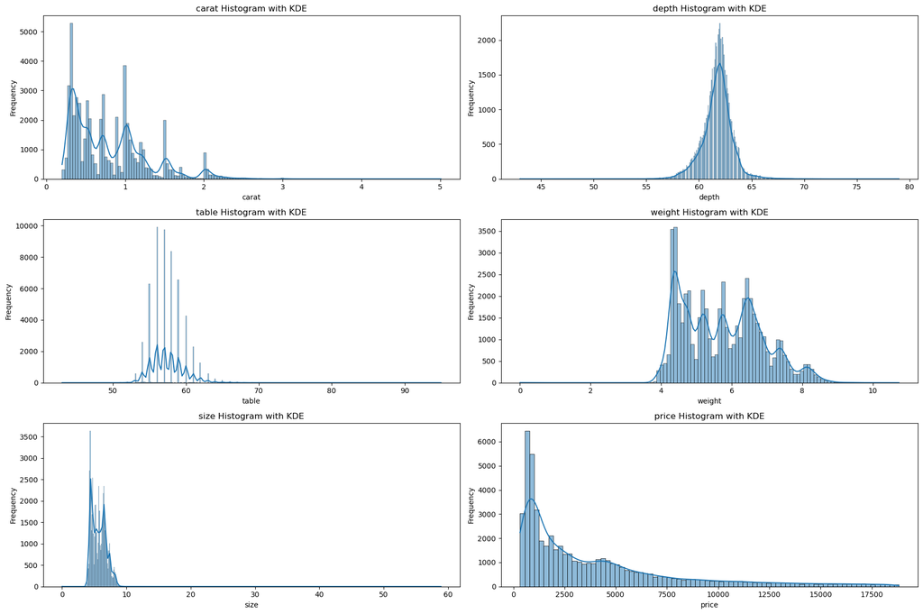

```python
plt.figure(figsize=(18, 12))
for i, column in enumerate(num_variables, 1):
    if i>6:
        break
    plt.subplot(3, 2, i)
    sns.histplot(num_variables[column], kde=True)
    plt.title(f'{column} Histogram with KDE')
    plt.xlabel(column)
    plt.ylabel('Frequency')

plt.tight_layout()
plt.show()
```

I. Check the correlation between all the numeric variables using HeatMap and try to draw some conclusion about the data.

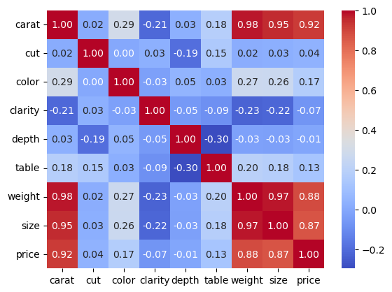

```python
b=a.corr()
sns.heatmap(b, annot=True, cmap='coolwarm', fmt='.2f')
```

```python
#1. Carat and Price: There is a very strong positive correlation (0.92) between carat and price, indicating that as the carat size of a diamond increases, its price also tends to increase.

#2. Size and Price: Size has a strong positive correlation (0.87) with price.

#3. Carat and Weight: Carat and weight are also correlated (0.98).

#4. Carat and Size: Carat and size also have a very high positive correlation (0.95).
```

Q2. Explain Gradient descent in detail. How changing the values of learning rate can impact the convergence in Gradient Descent.

Gradient Descent- It is a process which is used in Machine learning to reduce the loss. we will take an intial value and than we will iterate it until it reaches the point where x=0 and it is called Global Minima. first my model will calculate the slope which is delta of loss divided by delta of weight where weight is hyperparameter and it will iterate till the point of global minima and this is the point where we will be having the minimum loss.

Changing the values of Learning rate- General consideration for learning rate is 0.3 and if we will reduce the learning rate we will still get the result but Epoch will increase which means it will take more iteration due to this it take more time and If we will increase the learning rate it will keep jumping from one point to another and will become a loop but will never reach the global minima.